# Module_1_Quantium

Chanyanart KiattipornOpas

10/16/2021

## Part 1: Data Preparation and Data Cleansing

### 1.1 Download Library

```r
library(tidyverse)
library(readxl)
library(viridis)
```

### 1.2 Import Data into Rstudio

There are 2 datasets from Quantium, which are “Customer Data” in csv.file and “Transaction Data” in excel file, so we will download these dataset into Rstudio with read_csv and read_excel

```r
transaction <- read_excel("QVI_transaction_data.xlsx")

customer <- read_csv("QVI_purchase_behaviour.csv")
```

### 1.3 Explore Dataset

```r
glimpse(transaction)
```

```
## Rows: 264,836
## Columns: 8
## $ DATE           <dbl> 43390, 43599, 43605, 43329, 43330, 43604, 43601, 43601,~
## $ STORE_NBR      <dbl> 1, 1, 1, 2, 2, 4, 4, 4, 5, 7, 7, 8, 9, 13, 19, 20, 20, ~
## $ LYLTY_CARD_NBR <dbl> 1000, 1307, 1343, 2373, 2426, 4074, 4149, 4196, 5026, 7~
## $ TXN_ID         <dbl> 1, 348, 383, 974, 1038, 2982, 3333, 3539, 4525, 6900, 7~
## $ PROD_NBR       <dbl> 5, 66, 61, 69, 108, 57, 16, 24, 42, 52, 16, 114, 15, 92~
## $ PROD_NAME      <chr> "Natural Chip        Compny SeaSalt175g", "CCs Nacho Ch~
## $ PROD_QTY       <dbl> 2, 3, 2, 5, 3, 1, 1, 1, 1, 2, 1, 5, 2, 1, 1, 1, 4, 1, 1~
## $ TOT_SALES      <dbl> 6.0, 6.3, 2.9, 15.0, 13.8, 5.1, 5.7, 3.6, 3.9, 7.2, 5.7~
```

There are 8 columns with 264,836 Observations.

As I seen from data above, I found that some columns of data Type are incorrect, so I will convert data type.

```r
# To convert Numeric to Factor type
transaction$STORE_NBR <- as.factor(transaction$STORE_NBR)

transaction$LYLTY_CARD_NBR <- as.factor(transaction$LYLTY_CARD_NBR)

transaction$TXN_ID <- as.factor(transaction$TXN_ID)

transaction$PROD_NBR <- as.factor(transaction$PROD_NBR)

glimpse(transaction)
```

```
## Rows: 264,836
## Columns: 8
## $ DATE           <dbl> 43390, 43599, 43605, 43329, 43330, 43604, 43601, 43601,~
## $ STORE_NBR      <fct> 1, 1, 1, 2, 2, 4, 4, 4, 5, 7, 7, 8, 9, 13, 19, 20, 20, ~
## $ LYLTY_CARD_NBR <fct> 1000, 1307, 1343, 2373, 2426, 4074, 4149, 4196, 5026, 7~
## $ TXN_ID         <fct> 1, 348, 383, 974, 1038, 2982, 3333, 3539, 4525, 6900, 7~
## $ PROD_NBR       <fct> 5, 66, 61, 69, 108, 57, 16, 24, 42, 52, 16, 114, 15, 92~
## $ PROD_NAME      <chr> "Natural Chip        Compny SeaSalt175g", "CCs Nacho Ch~
## $ PROD_QTY       <dbl> 2, 3, 2, 5, 3, 1, 1, 1, 1, 2, 1, 5, 2, 1, 1, 1, 4, 1, 1~
## $ TOT_SALES      <dbl> 6.0, 6.3, 2.9, 15.0, 13.8, 5.1, 5.7, 3.6, 3.9, 7.2, 5.7~
```

```r
# Count distinct values of Loyalty Card Number column.
length(unique(transaction$LYLTY_CARD_NBR))
```

```
## [1] 72637
```

There are 72,637 unique Loyalty Card Number. However the record of transaction table has 264,836. This mean there are Repeat customers, they back to the store and bought products more than once, or bought many products.

```r
# Count distinct values of Store.
length(unique(transaction$STORE_NBR))
```

```
## [1] 272
```

```r
# Comment: There are 272 Stores where we collected.
```

```r
# To convert Numeric to Date type
transaction$DATE <- as.Date(transaction$DATE, origin = "1899-12-30")

# To check Earliest and Latest Transaction Date
min(transaction$DATE)
```

```
## [1] "2018-07-01"
```

```r
max(transaction$DATE)
```

```
## [1] "2019-06-30"
```

Earliest Transaction date is “2018-07-01”, and Latest Transaction date is “2019-06-30” from this dataset.

```r
# Count distinct values of DATE column.
length(unique(transaction$DATE))
```

```
## [1] 364
```

There are 364 days, which was collected. However, we already knew that Starting date is “2018-07-01” and End date is “2019-06-30”. It should have 365 days, So, we need to check the missing date. We will check after cleasing data.

Next, let check another dataset “customer”

```r
glimpse(customer)
```

```
## Rows: 72,637
## Columns: 3
## $ LYLTY_CARD_NBR   <dbl> 1000, 1002, 1003, 1004, 1005, 1007, 1009, 1010, 1011,~
## $ LIFESTAGE        <chr> "YOUNG SINGLES/COUPLES", "YOUNG SINGLES/COUPLES", "YO~
## $ PREMIUM_CUSTOMER <chr> "Premium", "Mainstream", "Budget", "Mainstream", "Mai~
```

There are 3 column with 72,637 Observations. All columns should be converted to factor.

```r
customer$LYLTY_CARD_NBR <- as.factor(customer$LYLTY_CARD_NBR)

customer %>% mutate_if(is.character, as.factor)
```

| LYLTY_CARD_NBR | LIFESTAGE | PREMIUM_CUSTOMER |
| --- | --- | --- |
| 1000 | YOUNG SINGLES/COUPLES | Premium |
| 1002 | YOUNG SINGLES/COUPLES | Mainstream |
| 1003 | YOUNG FAMILIES | Budget |
| 1004 | OLDER SINGLES/COUPLES | Mainstream |
| 1005 | MIDAGE SINGLES/COUPLES | Mainstream |
| 1007 | YOUNG SINGLES/COUPLES | Budget |
| 1009 | NEW FAMILIES | Premium |
| 1010 | YOUNG SINGLES/COUPLES | Mainstream |
| 1011 | OLDER SINGLES/COUPLES | Mainstream |
| 1012 | OLDER FAMILIES | Mainstream |

[output cut: 9990 more lines]

There are 72,637 rows/observation in this customer dataset, so we need to check that all this rows are unique? or some are duplicated?

```r
# To check distinct value of LYLTY_CARD_NBR of customer dataset.

length(unique(customer$LYLTY_CARD_NBR))
```

```
## [1] 72637
```

There are 72,637 unique card number == 72,637 rows. This mean each row represents each customer, There is no duplicate rows.

We also seen from “LYLTY_CARD_NBR of Transaction data” has 72,637 unique card number. Both dataset are matched both customer information and their transactions

```r
# To check distinct value of LIFESTAGE column
length(unique(customer$LIFESTAGE))
```

```
## [1] 7
```

There are 7 age groups, So let see the frequency of each group.

```r
# To check each age group and their frequency
lifestage_freq <- customer %>% count(LIFESTAGE) %>% arrange(desc(n))

lifestage_freq
```

| LIFESTAGE | n |
| --- | --- |
| RETIREES | 14805 |
| OLDER SINGLES/COUPLES | 14609 |
| YOUNG SINGLES/COUPLES | 14441 |
| OLDER FAMILIES | 9780 |
| YOUNG FAMILIES | 9178 |
| MIDAGE SINGLES/COUPLES | 7275 |
| NEW FAMILIES | 2549 |

```r
# To check distinct value of CUSTOMER Segment column
length(unique(customer$PREMIUM_CUSTOMER))
```

```
## [1] 3
```

There are 3 groups of customer segment, So let see the frequency of each group.

```r
# # To check each group of customer segment & frequency
preCus_freq <- customer %>% count(PREMIUM_CUSTOMER) %>% arrange(desc(n))

preCus_freq
```

| PREMIUM_CUSTOMER | n |
| --- | --- |
| Mainstream | 29245 |
| Budget | 24470 |
| Premium | 18922 |

### 1.4 Join dataset

As we seen from 2 dataset, we can join table with ‘customer loyalty card number’ which appeared on both dataset.

```r
all <- transaction %>%
    left_join(customer, by = "LYLTY_CARD_NBR")
```

This two dataset is joined by left_join. Then, we will check NULL from our new dataset.

### 1.5 Check Null

There are 264,836 observations. So, we will check how many observation complete?

```r
# How many observations complete ? - count TRUE
sum(complete.cases(all))
```

```
## [1] 264836
```

```r
# Comment: 264,836 == 264,836

mean(complete.cases(all))
```

```
## [1] 1
```

```r
# Comment: 1, means all observation are completed.
```

### 1.6 Remove Outliers

Take a look on Outliers by using summary()

```r
summary(all)
```

```
##       DATE              STORE_NBR      LYLTY_CARD_NBR       TXN_ID
##  Min.   :2018-07-01   226    :  2022   162039 :    18   1162   :     3
##  1st Qu.:2018-09-30   88     :  1873   172032 :    18   102237 :     3
##  Median :2018-12-30   93     :  1832   13138  :    17   108462 :     3
##  Mean   :2018-12-30   165    :  1819   116181 :    17   211119 :     3
##  3rd Qu.:2019-03-31   237    :  1785   128178 :    17   222775 :     3
##  Max.   :2019-06-30   43     :  1771   230078 :    17   228741 :     3
##                       (Other):253734   (Other):264732   (Other):264818
##     PROD_NBR       PROD_NAME            PROD_QTY         TOT_SALES
##  102    :  3304   Length:264836      Min.   :  1.000   Min.   :  1.500
##  108    :  3296   Class :character   1st Qu.:  2.000   1st Qu.:  5.400
##  33     :  3269   Mode  :character   Median :  2.000   Median :  7.400
##  112    :  3268                      Mean   :  1.907   Mean   :  7.304
##  75     :  3265                      3rd Qu.:  2.000   3rd Qu.:  9.200
##  63     :  3257                      Max.   :200.000   Max.   :650.000
##  (Other):245177
##   LIFESTAGE         PREMIUM_CUSTOMER
##  Length:264836      Length:264836
##  Class :character   Class :character
##  Mode  :character   Mode  :character
##
##
##
##
```

There are outliers from ‘PROD_QTY’ and ‘TOT_SALES’ column which shown Max number out far from 3rd quartile.

```r
all %>% filter(PROD_QTY == 200.000)
```

| DATE | STORE_NBR | LYLTY_CARD_NBR | TXN_ID | PROD_NBR | PROD_NAME | PROD_QTY | TOT_SALES | LIFESTAGE | PREMIUM_CUSTOMER |
| --- | --- | --- | --- | --- | --- | --- | --- | --- | --- |
| 2018-08-19 | 226 | 226000 | 226201 | 4 | Dorito Corn Chp Supreme 380g | 200 | 650 | OLDER FAMILIES | Premium |
| 2019-05-20 | 226 | 226000 | 226210 | 4 | Dorito Corn Chp Supreme 380g | 200 | 650 | OLDER FAMILIES | Premium |

```r
all %>% filter(TOT_SALES == 650.000 )
```

| DATE | STORE_NBR | LYLTY_CARD_NBR | TXN_ID | PROD_NBR | PROD_NAME | PROD_QTY | TOT_SALES | LIFESTAGE | PREMIUM_CUSTOMER |
| --- | --- | --- | --- | --- | --- | --- | --- | --- | --- |
| 2018-08-19 | 226 | 226000 | 226201 | 4 | Dorito Corn Chp Supreme 380g | 200 | 650 | OLDER FAMILIES | Premium |
| 2019-05-20 | 226 | 226000 | 226210 | 4 | Dorito Corn Chp Supreme 380g | 200 | 650 | OLDER FAMILIES | Premium |

So, Let’s see other transaction that this customer made.

```r
all %>% filter(LYLTY_CARD_NBR == 226000)
```

| DATE | STORE_NBR | LYLTY_CARD_NBR | TXN_ID | PROD_NBR | PROD_NAME | PROD_QTY | TOT_SALES | LIFESTAGE | PREMIUM_CUSTOMER |
| --- | --- | --- | --- | --- | --- | --- | --- | --- | --- |
| 2018-08-19 | 226 | 226000 | 226201 | 4 | Dorito Corn Chp Supreme 380g | 200 | 650 | OLDER FAMILIES | Premium |
| 2019-05-20 | 226 | 226000 | 226210 | 4 | Dorito Corn Chp Supreme 380g | 200 | 650 | OLDER FAMILIES | Premium |

It looks like this customer has only had the two transactions over the year and is not an ordinary retail customer. The customer might be buying chips for commercial purposes instead. We’ll remove this loyalty card number from further analysis.

```r
all <- all %>% filter(LYLTY_CARD_NBR != 226000)

#  264,834 Observations/rows

summary(all)
```

```
##       DATE              STORE_NBR      LYLTY_CARD_NBR       TXN_ID
##  Min.   :2018-07-01   226    :  2020   162039 :    18   1162   :     3
##  1st Qu.:2018-09-30   88     :  1873   172032 :    18   102237 :     3
##  Median :2018-12-30   93     :  1832   13138  :    17   108462 :     3
##  Mean   :2018-12-30   165    :  1819   116181 :    17   211119 :     3
##  3rd Qu.:2019-03-31   237    :  1785   128178 :    17   222775 :     3
##  Max.   :2019-06-30   43     :  1771   230078 :    17   228741 :     3
##                       (Other):253734   (Other):264730   (Other):264816
##     PROD_NBR       PROD_NAME            PROD_QTY       TOT_SALES
##  102    :  3304   Length:264834      Min.   :1.000   Min.   : 1.500
##  108    :  3296   Class :character   1st Qu.:2.000   1st Qu.: 5.400
##  33     :  3269   Mode  :character   Median :2.000   Median : 7.400
##  112    :  3268                      Mean   :1.906   Mean   : 7.299
##  75     :  3265                      3rd Qu.:2.000   3rd Qu.: 9.200
##  63     :  3257                      Max.   :5.000   Max.   :29.500
##  (Other):245175
##   LIFESTAGE         PREMIUM_CUSTOMER
##  Length:264834      Length:264834
##  Class :character   Class :character
##  Mode  :character   Mode  :character
##
##
##
##
```

### 1.7 String Manipulation

According to product name column, we should separate product name and product size.

```r
# To create New column "PACK_SIZE" and Extract only number from PROD_NAME

all["PACK_SIZE"] <- str_extract(all$PROD_NAME, "\\d+")

# To convert the data type from Character to numeric
all$PACK_SIZE <- as.double(all$PACK_SIZE)
head(all)
```

| DATE | STORE_NBR | LYLTY_CARD_NBR | TXN_ID | PROD_NBR | PROD_NAME | PROD_QTY | TOT_SALES | LIFESTAGE | PREMIUM_CUSTOMER | PACK_SIZE |
| --- | --- | --- | --- | --- | --- | --- | --- | --- | --- | --- |
| 2018-10-17 | 1 | 1000 | 1 | 5 | Natural Chip Compny SeaSalt175g | 2 | 6.0 | YOUNG SINGLES/COUPLES | Premium | 175 |
| 2019-05-14 | 1 | 1307 | 348 | 66 | CCs Nacho Cheese 175g | 3 | 6.3 | MIDAGE SINGLES/COUPLES | Budget | 175 |
| 2019-05-20 | 1 | 1343 | 383 | 61 | Smiths Crinkle Cut Chips Chicken 170g | 2 | 2.9 | MIDAGE SINGLES/COUPLES | Budget | 170 |
| 2018-08-17 | 2 | 2373 | 974 | 69 | Smiths Chip Thinly S/Cream&Onion 175g | 5 | 15.0 | MIDAGE SINGLES/COUPLES | Budget | 175 |
| 2018-08-18 | 2 | 2426 | 1038 | 108 | Kettle Tortilla ChpsHny&Jlpno Chili 150g | 3 | 13.8 | MIDAGE SINGLES/COUPLES | Budget | 150 |
| 2019-05-19 | 4 | 4074 | 2982 | 57 | Old El Paso Salsa Dip Tomato Mild 300g | 1 | 5.1 | MIDAGE SINGLES/COUPLES | Budget | 300 |

```r
# To remove the Punctuation and Pack size from Product name
all$PROD_NAME <- str_replace_all(all$PROD_NAME, "[[:punct:]]", " ")

all$PROD_NAME <- str_replace_all(all$PROD_NAME, "[0-9]++[gG]", " ")
```

```r
# To trim extra white space
all$PROD_NAME <- gsub("\\s+"," ", all$PROD_NAME)

# To Convert First letter of every word to Uppercase
all$PROD_NAME <- str_to_title(all$PROD_NAME)
```

```r
# To extract the name of brand
all$BRAND <- gsub("([A-Za-z]+).*", "\\1", all$PROD_NAME)
```

```r
# Let's count Brand name
summary(as_factor(all$BRAND))
```

```
##    Natural        Ccs     Smiths     Kettle        Old      Grain    Doritos
##       6050       4551      28860      41288       9324       6272      24962
##   Twisties         Ww      Thins     Burger        Ncc   Cheezels     Infzns
##       9454      10320      14075       1564       1419       4603       3144
##        Red   Pringles     Dorito  Infuzions      Smith    Grnwves   Tyrrells
##       5885      25102       3183      11057       2963       1468       6442
##       Cobs Woolworths     French        Rrd   Tostitos    Cheetos      Snbts
##       9693       4437       1418      11894       9471       2927       1576
##   Sunbites
##       1432
```

```r
# Rename the duplicated brand name
all$BRAND <- gsub("Red", "Rrd", all$BRAND)
all$BRAND <- gsub("Doritos", "Dorito", all$BRAND)
all$BRAND <- gsub("Snbts", "Sunbites", all$BRAND)
all$BRAND <- gsub("Ncc", "Natural", all$BRAND)
all$BRAND <- gsub("Smiths", "Smith", all$BRAND)
all$BRAND <- gsub("Ww", "Woolworths", all$BRAND)
all$BRAND <- gsub("Infzns","Infuzions", all$BRAND)
```

```r
all$BRAND <- gsub("Dorito", "Doritos", all$BRAND)

summary(as_factor(all$BRAND))
```

```
##    Natural        Ccs      Smith     Kettle        Old      Grain    Doritos
##       7469       4551      31823      41288       9324       6272      28145
##   Twisties Woolworths      Thins     Burger   Cheezels  Infuzions        Rrd
##       9454      14757      14075       1564       4603      14201      17779
##   Pringles    Grnwves   Tyrrells       Cobs     French   Tostitos    Cheetos
##      25102       1468       6442       9693       1418       9471       2927
##   Sunbites
##       3008
```

### 1.8 Drop Irrelevant data

There are salsa products in the dataset but we are only interested in the chips category.

```r
# To drop the rows that contain 'Salsa'

sum(str_detect(all$PROD_NAME, pattern = "Salsa"))
```

```
## [1] 18094
```

```r
# There are 18,094 products containing words "Salsa"

all <- all %>% filter(grepl("Salsa", all$PROD_NAME)== FALSE)

glimpse(all)
```

```
## Rows: 246,740
## Columns: 12
## $ DATE             <date> 2018-10-17, 2019-05-14, 2019-05-20, 2018-08-17, 2018~
## $ STORE_NBR        <fct> 1, 1, 1, 2, 2, 4, 4, 5, 7, 7, 8, 9, 13, 19, 20, 20, 2~
## $ LYLTY_CARD_NBR   <fct> 1000, 1307, 1343, 2373, 2426, 4149, 4196, 5026, 7150,~
## $ TXN_ID           <fct> 1, 348, 383, 974, 1038, 3333, 3539, 4525, 6900, 7176,~
## $ PROD_NBR         <fct> 5, 66, 61, 69, 108, 16, 24, 42, 52, 16, 114, 15, 92, ~
## $ PROD_NAME        <chr> "Natural Chip Compny Seasalt ", "Ccs Nacho Cheese ", ~
## $ PROD_QTY         <dbl> 2, 3, 2, 5, 3, 1, 1, 1, 2, 1, 5, 2, 1, 1, 1, 4, 1, 1,~
## $ TOT_SALES        <dbl> 6.0, 6.3, 2.9, 15.0, 13.8, 5.7, 3.6, 3.9, 7.2, 5.7, 2~
## $ LIFESTAGE        <chr> "YOUNG SINGLES/COUPLES", "MIDAGE SINGLES/COUPLES", "M~
## $ PREMIUM_CUSTOMER <chr> "Premium", "Budget", "Budget", "Budget", "Budget", "B~
## $ PACK_SIZE        <dbl> 175, 175, 170, 175, 150, 330, 210, 150, 210, 330, 150~
## $ BRAND            <chr> "Natural", "Ccs", "Smith", "Smith", "Kettle", "Smith"~
```

```r
# 246,740 Observations (264,834 - 18,094)
```

### 1.9 Examine Date data

```r
# To summary of transaction count by Date
date_freq <- all %>% count(DATE) %>% arrange(desc(n))
```

There are 364 days. However, we have 365 days in a year. So, what is missing date?

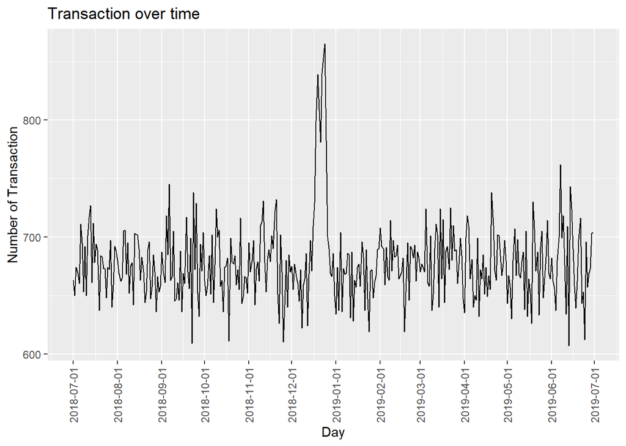

```r
# Create the graph to show the peak of sales
p_date <- ggplot(date_freq, aes(DATE,n)) +
    geom_line() +
    labs(x = "Day",
         y = "Number of Transaction",
         title = "Transaction over time") +
    scale_x_date(breaks = "1 month") +
    theme(axis.text.x = element_text(angle = 90,
                                     vjust = 0.5))

p_date
```

We clearly see that the increase of purchasing snack in December. So, we will close up look what date are.

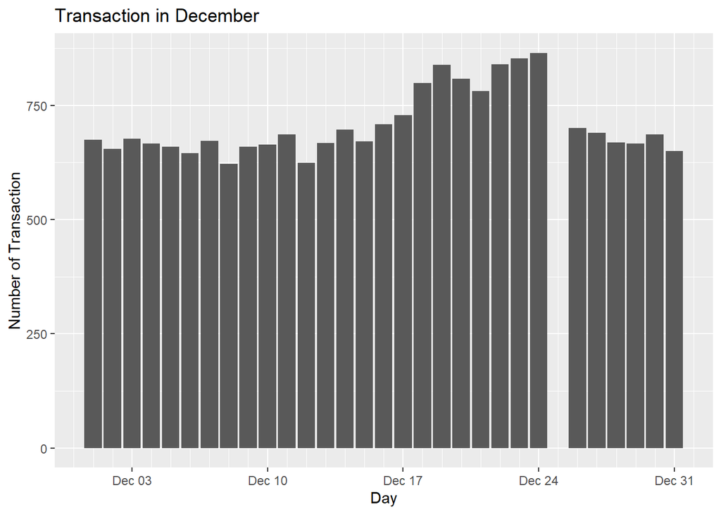

```r
decem <- date_freq %>% select(DATE,n) %>%
    filter(DATE >= as.Date("2018-12-01") & DATE <= as.Date("2018-12-31")) %>%
    arrange(desc(n))

p_decem <- ggplot(decem,aes(DATE,n)) +
    geom_col() +
    labs(x = "Day",
         y = "Number of Transaction",
         title = "Transaction in December") +
    scale_x_date(date_minor_breaks = "1 day")

p_decem
```

We can see that the increase in sales occurs in the lead-up to Christmas and that there are zero sales on Christmas day itself. This is due to shops being closed on Christmas day.

### 2.10 Save and Export cleaned data from Rstudio

```r
write_csv(all,"QVI_data.csv")
```

## Part 2: Data Exploration

### 2.1 Which brand is the most favorite brand ?

```r
# Count all brands from Transaction data
brand_freq <- all %>% count(BRAND) %>% arrange(desc(n))

brand_freq
```

| BRAND | n |
| --- | --- |
| Kettle | 41288 |
| Smith | 30353 |
| Doritos | 25224 |
| Pringles | 25102 |
| Rrd | 16321 |
| Infuzions | 14201 |
| Thins | 14075 |
| Woolworths | 11836 |
| Cobs | 9693 |
| Tostitos | 9471 |

[output cut: 11 more lines]

There are 21 brands in this transaction data. ‘Kettle’ is the most favorite brand of chips(41,288 transaction). Then, ‘Smith’ (30353 transaction) and ‘Doritos’ (25,224)

The least popular brand is ‘French’ 1,418 transaction

### 2.2 Which brand made the high profit ?

```r
# To sum Total Sales by Brand
top_sale_brand <- all %>%
  select(BRAND, TOT_SALES) %>%
  group_by(BRAND) %>%
  summarize(total = sum(TOT_SALES)) %>%
  arrange(desc(total))

top_sale_brand
```

| BRAND | total |
| --- | --- |
| Kettle | 390239.8 |
| Doritos | 226329.9 |
| Smith | 217492.0 |
| Pringles | 177655.5 |
| Infuzions | 99047.6 |
| Thins | 88852.5 |
| Rrd | 87607.5 |
| Twisties | 81522.1 |
| Tostitos | 79789.6 |
| Cobs | 70569.8 |

[output cut: 11 more lines]

And, again ‘Kettle’ is still be the first brand which highest profit compared with others. ($390,239.8)

However, the second and third rank are swap the places from above. ‘Doritos’ ($ 226329.9) now comes to second place which made higher profit than ‘Smith’ (217,492)

The lowest profit is ‘Burger’ brand, it just $ 6,831

### 2.3 How many customers in each age group?

```r
# To check age group
lifestage_freq <- customer %>% count(LIFESTAGE) %>% arrange(desc(n))

lifestage_freq
```

| LIFESTAGE | n |
| --- | --- |
| RETIREES | 14805 |
| OLDER SINGLES/COUPLES | 14609 |
| YOUNG SINGLES/COUPLES | 14441 |
| OLDER FAMILIES | 9780 |
| YOUNG FAMILIES | 9178 |
| MIDAGE SINGLES/COUPLES | 7275 |
| NEW FAMILIES | 2549 |

Table shows that “RETIRE” is the large group of customers who held the Loyalty Card (14,805). OLDER and YOUNG SINGLES/COUPLES are comes to the second and the third group (14,609 and 14,441 respectively).

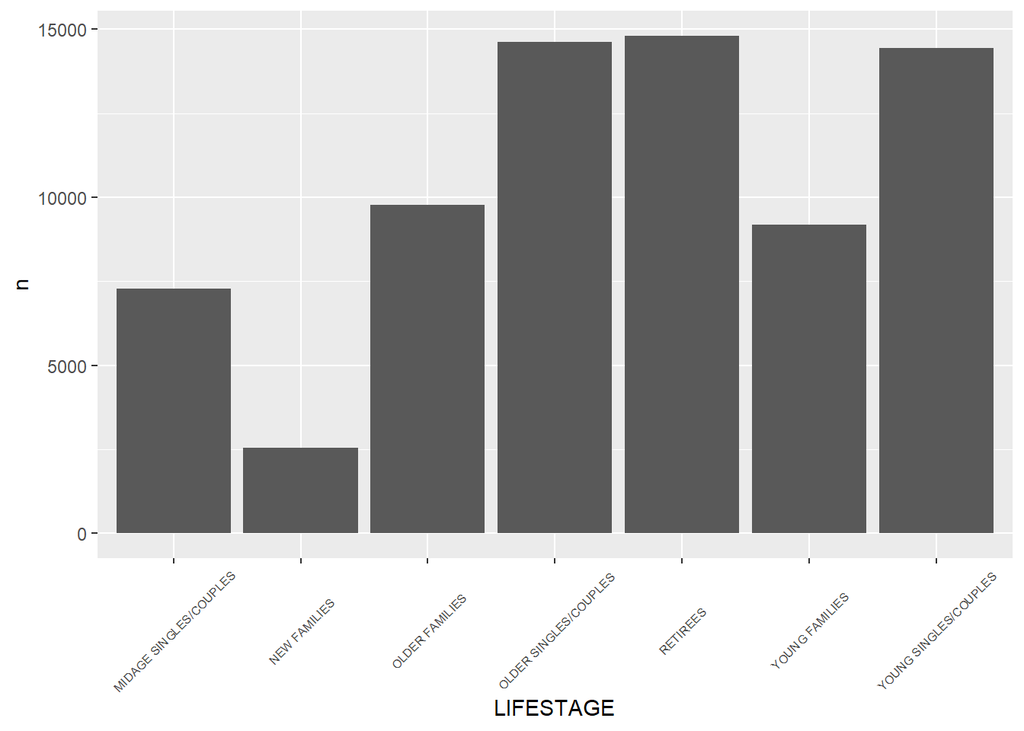

```r
lifestage_freq %>% ggplot(aes(LIFESTAGE,n)) +
  geom_col() +
  theme(axis.text.x = element_text(angle = 45,
                                  vjust = 0.5,
                                   size = 6))
```

The lowest amount of customer group which held the Loyalty Card is NEW FAMILIES(2,549).

### 2.4 How many customers in each purchasing group?

```r
# To count number of people by PREMIUM_CUSTOMER
preCus_freq <- customer %>% count(PREMIUM_CUSTOMER) %>% arrange(desc(n))

preCus_freq
```

| PREMIUM_CUSTOMER | n |
| --- | --- |
| Mainstream | 29245 |
| Budget | 24470 |
| Premium | 18922 |

‘Mainstream’ is the highest group of customer (29,245). The following are ‘Budget’(24,470) and ‘Premium’ (18,922).

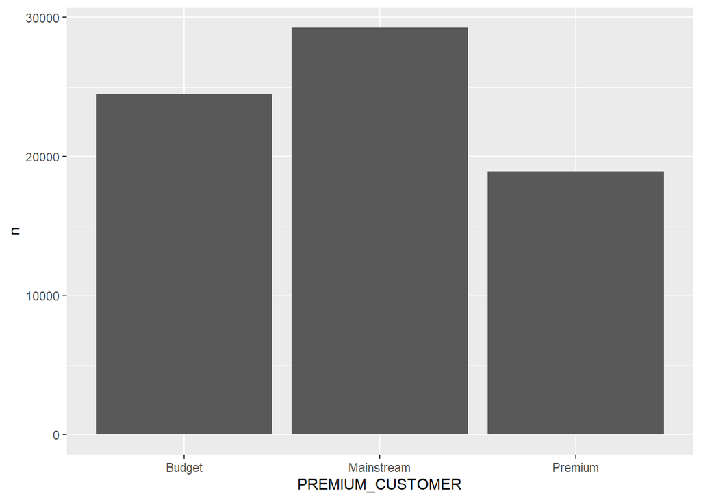

```r
preCus_freq %>% ggplot(aes(PREMIUM_CUSTOMER, n)) +
  geom_col()
```

## Part 3: Data Analysis on Customer Segments

Now, we can define some metrics of interest to the client:

- How many customers are in each segment
- Who spends the most on chips (total sales), describing customers by life stage and how premium their general purchasing behaviour is
- How many chips are bought per customer by segment
- What’s the average chip price by customer segment

### 3.1 How many customers are in each segment?

```r
# Customer by Life Stage and Premium rank

all %>% group_by(PREMIUM_CUSTOMER, LIFESTAGE) %>%
  summarize(count = n_distinct(LYLTY_CARD_NBR)) %>%
  arrange(desc(count))
```

| PREMIUM_CUSTOMER | LIFESTAGE | count |
| --- | --- | --- |
| Mainstream | YOUNG SINGLES/COUPLES | 7917 |
| Mainstream | RETIREES | 6358 |
| Mainstream | OLDER SINGLES/COUPLES | 4858 |
| Budget | OLDER SINGLES/COUPLES | 4849 |
| Premium | OLDER SINGLES/COUPLES | 4682 |
| Budget | OLDER FAMILIES | 4611 |
| Budget | RETIREES | 4385 |
| Budget | YOUNG FAMILIES | 3953 |
| Premium | RETIREES | 3812 |
| Budget | YOUNG SINGLES/COUPLES | 3647 |

[output cut: 11 more lines]

If we combine the Life Stage with Purchasing behavior(Premium_customer), we could see the result that ‘Mainstream Class of YOUNG SINGLES/COUPLES’ is the main group of customer in our company, who held the Loyalty card. They has a highest proportion (7,917 peoples)

‘Retired with Mainstream class’ comes to the second place (6,358) and the third place is ‘OLDER SINGLES/COUPLES with mainstream class’ which far behind the second place. (4,858 peoples)

However, Our number of customers in each group does not guarantee the profit and total sales that company received. So, we need to explore the total sales of each group again below.

### 3.2 Who spends the most on chips (total sales), describing customers by life stage and how premium their general purchasing behavior is

```r
all %>% group_by(PREMIUM_CUSTOMER, LIFESTAGE) %>%
  summarize(total_sale = sum(TOT_SALES),) %>%
  arrange(desc(total_sale))
```

| PREMIUM_CUSTOMER | LIFESTAGE | total_sale |
| --- | --- | --- |
| Budget | OLDER FAMILIES | 156863.75 |
| Mainstream | YOUNG SINGLES/COUPLES | 147582.20 |
| Mainstream | RETIREES | 145168.95 |
| Budget | YOUNG FAMILIES | 129717.95 |
| Budget | OLDER SINGLES/COUPLES | 127833.60 |
| Mainstream | OLDER SINGLES/COUPLES | 124648.50 |
| Premium | OLDER SINGLES/COUPLES | 123537.55 |
| Budget | RETIREES | 105916.30 |
| Mainstream | OLDER FAMILIES | 96413.55 |
| Premium | RETIREES | 91296.65 |

[output cut: 11 more lines]

From the table, We found that ‘Older families of Budget segment’ has the highest sales of purchasing Chips. ($ 156,863.75)

It is striking that the second and the third place swap the place.’YOUNG SINGLES/COUPLES with mainstream class’ now is second place with total sales is 147,582. But ‘Retired with Mainstream class’ goes down to the third place (145,168.95)

### 3.3 How many chips are bought per customer by segment

```r
all %>% group_by(PREMIUM_CUSTOMER, LIFESTAGE) %>%
  summarize( totalChip = sum(PROD_QTY),
              aveUnitPerCustomer = mean(PROD_QTY)) %>%
  arrange(desc(aveUnitPerCustomer))
```

| PREMIUM_CUSTOMER | LIFESTAGE | totalChip | aveUnitPerCustomer |
| --- | --- | --- | --- |
| Mainstream | OLDER FAMILIES | 25804 | 1.948795 |
| Premium | OLDER FAMILIES | 20239 | 1.945496 |
| Budget | OLDER FAMILIES | 41853 | 1.945384 |
| Mainstream | YOUNG FAMILIES | 23194 | 1.941408 |
| Budget | YOUNG FAMILIES | 34482 | 1.941226 |
| Premium | YOUNG FAMILIES | 20901 | 1.938149 |
| Budget | OLDER SINGLES/COUPLES | 32883 | 1.914920 |
| Premium | OLDER SINGLES/COUPLES | 31695 | 1.913949 |
| Mainstream | MIDAGE SINGLES/COUPLES | 21213 | 1.911942 |
| Mainstream | OLDER SINGLES/COUPLES | 32607 | 1.911201 |

[output cut: 11 more lines]

Older families and young families in general buy more chips per customer.

### 3.4 What’s the average chip price by customer segment

```r
Customer_Seg <- all %>%
          group_by(PREMIUM_CUSTOMER, LIFESTAGE) %>%
          summarize(aveUnitPerCustomer =
                    sum(TOT_SALES)/sum(PROD_QTY)) %>%
          arrange(desc(aveUnitPerCustomer))

Customer_Seg
```

| PREMIUM_CUSTOMER | LIFESTAGE | aveUnitPerCustomer |
| --- | --- | --- |
| Mainstream | YOUNG SINGLES/COUPLES | 4.074043 |
| Mainstream | MIDAGE SINGLES/COUPLES | 3.994449 |
| Mainstream | NEW FAMILIES | 3.935887 |
| Budget | RETIREES | 3.932731 |
| Budget | NEW FAMILIES | 3.931969 |
| Premium | RETIREES | 3.924037 |
| Premium | OLDER SINGLES/COUPLES | 3.897698 |
| Budget | OLDER SINGLES/COUPLES | 3.887529 |
| Premium | NEW FAMILIES | 3.886168 |
| Mainstream | RETIREES | 3.852986 |

[output cut: 11 more lines]

Mainstream mid-age and young singles and couples are more willing to pay more per packet of chips compared to their budget and premium counterparts. This may be due to premium shoppers being more likely to buy healthy snacks and when they buy chips, this is mainly for entertainment purposes rather than their own consumption. This is also supported by there being fewer premium mid-age and young singles and couples buying chips compared to their mainstream counterparts.

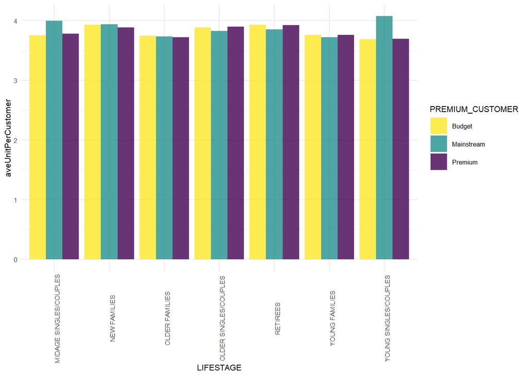

```r
# To compare each segment by average chip prices
Customer_Seg %>%
ggplot(aes(LIFESTAGE, aveUnitPerCustomer,
                 fill = PREMIUM_CUSTOMER)) +
  geom_col(position = "dodge", alpha = 0.8) +
  theme_minimal(base_size = 8) +
  theme(axis.text.x = element_text(angle = 90)) +
  scale_fill_viridis(discrete = TRUE, direction = -1)
```

There are some interesting on the graph above, Mainstream class of Mid-age and Young Single/Couples group - look higher than other groups.

As the difference in average price per unit isn’t large, we can check if this difference is statistically different.

### 3.5 Perform an independent t-test between “mainstream vs premium/ budget” of Young & Mid-Age singles/couples

```r
# To create new column of Average sales per Unit
all <- all %>% mutate(aveUnitPerCustomer = TOT_SALES/PROD_QTY)
```

```r
# Separate between 2 groups of Mainstream and Non Mainstream
mainStream <- all %>%
  filter(LIFESTAGE == c("YOUNG SINGLES/COUPLES",
                        "MIDAGE SINGLES/COUPLES") &
           PREMIUM_CUSTOMER == "Mainstream")

nonMainStream <- all %>%
  filter(LIFESTAGE == c("YOUNG SINGLES/COUPLES",
                        "MIDAGE SINGLES/COUPLES") &
           PREMIUM_CUSTOMER != "Mainstream")
```

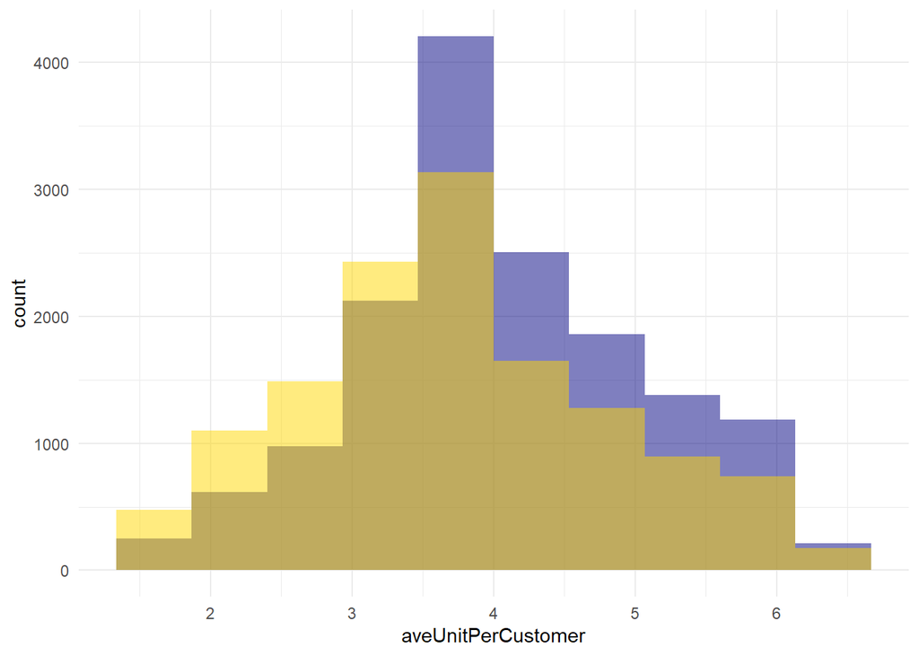

```r
ggplot() +
          geom_histogram(data = mainStream,
                         mapping = aes(aveUnitPerCustomer),
                         bins = 10, fill ="navy",
                         alpha = 0.5) +
          geom_histogram(data = nonMainStream,
                         mapping = aes(aveUnitPerCustomer),
                         bins = 10, fill="gold",
                         alpha = 0.5) +
  theme_minimal()
```

```r
t.test(mainStream$aveUnitPerCustomer,
       nonMainStream$aveUnitPerCustomer)
```

```
##
##  Welch Two Sample t-test
##
## data:  mainStream$aveUnitPerCustomer and nonMainStream$aveUnitPerCustomer
## t = 25.771, df = 27436, p-value < 2.2e-16
## alternative hypothesis: true difference in means is not equal to 0
## 95 percent confidence interval:
##  0.2977693 0.3467931
## sample estimates:
## mean of x mean of y
##  4.039745  3.717464
```

### 3.6 Deep dive into Mainstream, young singles/couples. Do they tend to buy a particular of Chips?

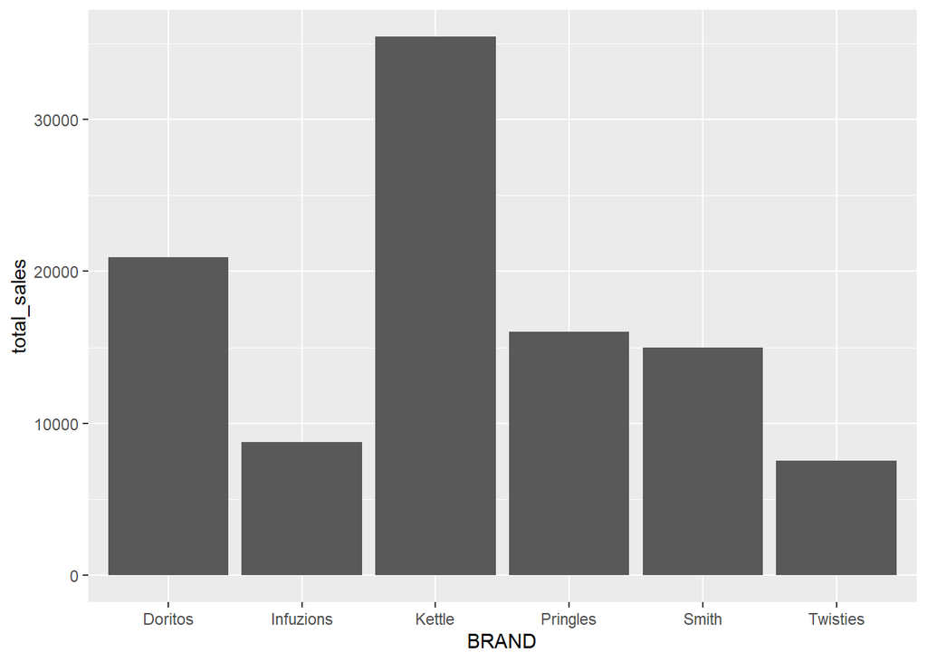

```r
# Let's find which brand they bought, Do they tend to buy a particular of Chips?

mainStream_Young <- all %>%
  filter(LIFESTAGE == "YOUNG SINGLES/COUPLES"
         & PREMIUM_CUSTOMER == "Mainstream") %>%
  group_by(BRAND) %>%
  summarize(total_sales = sum(TOT_SALES)) %>%
  arrange(desc(total_sales)) %>%
  head()

ggplot(mainStream_Young, aes(BRAND, total_sales)) +
  geom_col()
```

Kettle and Doritos is the top 2 of purchasing for Mainstream, young singles/couples Group.

### 3.7 Most Favourite Brand with Pack Size

```r
all %>% filter(LIFESTAGE == "YOUNG SINGLES/COUPLES" &
                 PREMIUM_CUSTOMER == "Mainstream") %>%
  group_by(BRAND,as.factor(PACK_SIZE)) %>%
  summarize(total_sales = sum(TOT_SALES)) %>%
  arrange(desc(total_sales))
```

| BRAND | as.factor(PACK_SIZE) | total_sales |
| --- | --- | --- |
| Kettle | 175 | 17863.2 |
| Pringles | 134 | 16006.2 |
| Kettle | 150 | 15313.4 |
| Doritos | 170 | 9996.8 |
| Infuzions | 110 | 8485.4 |
| Tostitos | 175 | 7238.0 |
| Thins | 175 | 7217.1 |
| Smith | 330 | 6378.3 |
| Cobs | 110 | 6144.6 |
| Twisties | 270 | 5303.8 |

[output cut: 28 more lines]

Both brands of pack size are not much different, but shows a big gap of total sales.

### 3.8 Brand Affinity

```r
# Comparing between the group of Young/Mainstream and others. Spilt into two groups.
young_main <- all %>% filter(
              LIFESTAGE == "YOUNG SINGLES/COUPLES" &
              PREMIUM_CUSTOMER == "Mainstream")

other_group <- all %>% filter(
              LIFESTAGE != "YOUNG SINGLES/COUPLES" &
              PREMIUM_CUSTOMER != "Mainstream")
```

```r
# Sum the purchasing quantity in each group.
quantity_youngMain <- young_main %>%
                      summarize(sum(PROD_QTY))

quantity_other <- other_group %>%
                      summarize(sum(PROD_QTY))
```

```r
# Brand Affinity compared to the rest of the population

young_main_byBrand <- young_main %>%
  group_by(BRAND) %>%
  summarize(target = sum(PROD_QTY)/quantity_youngMain)

other_group_byBrand <- other_group %>%
  group_by(BRAND) %>%
  summarize(other = sum(PROD_QTY)/quantity_other)
```

```r
# Which brand had high Affinity to Brand?

brand_proportions <- inner_join(young_main_byBrand, other_group_byBrand, by = "BRAND") %>%
  mutate(affinityToBrand = target/other ) %>%
  arrange(desc(affinityToBrand))

brand_proportions
```

[output not shown]

[output cut: 11 more lines]

Mainstream young singles/couples are more likely to purchase “Tyrrells” chips compared to the rest of the population

Mainstream young singles/couples are less likely to purchase “Burger” compared to the rest of the population

### 3.9 Preferred Pack Size

Let’s also find out if our target segment tends to buy larger packs of chips.

```r
# Preferred pack size compared to the rest of the population

young_main_byPack <- young_main %>% group_by(PACK_SIZE) %>%
  summarize(target = sum(PROD_QTY)/quantity_youngMain)

other_group_byPack<- other_group %>% group_by(PACK_SIZE) %>%
  summarize(other = sum(PROD_QTY)/quantity_other)
```

```r
# Which Pack Size is the most favorite for Young/Mainstream group?

pack_proportions <- inner_join(young_main_byPack, other_group_byPack, by = "PACK_SIZE") %>%
  mutate(affinityToPack = target/other ) %>%
  arrange(desc(affinityToPack))
```

```r
all %>% select(PROD_NAME, PACK_SIZE) %>%
        filter(PACK_SIZE == 270) %>% count(PROD_NAME)
```

| PROD_NAME | n |
| --- | --- |
| Twisties Cheese | 3115 |
| Twisties Chicken | 3170 |

## Conclusion

The groups that spends the most on chips (total sales) are from - Budget OLDER FAMILIES  
- Mainstream YOUNG SINGLES/COUPLES  
- Mainstream RETIREES

“Kettle” is the most favorite brand with high total sales.

Mainstream mid-age and young singles and couples are more willing to pay more per packet of chips compared to their budget and premium.